# SSA

Romanova

25 апреля 2019 г

# 1 Анализ конкретного временного ряда

## 1.1 Общие вещи

Рассматриваемый ряд – уровень женской безработицы с 1948 по 2018 год, измеренный в процентах неработающих женщин относительно всех женщин, которые имеют возможность работать.

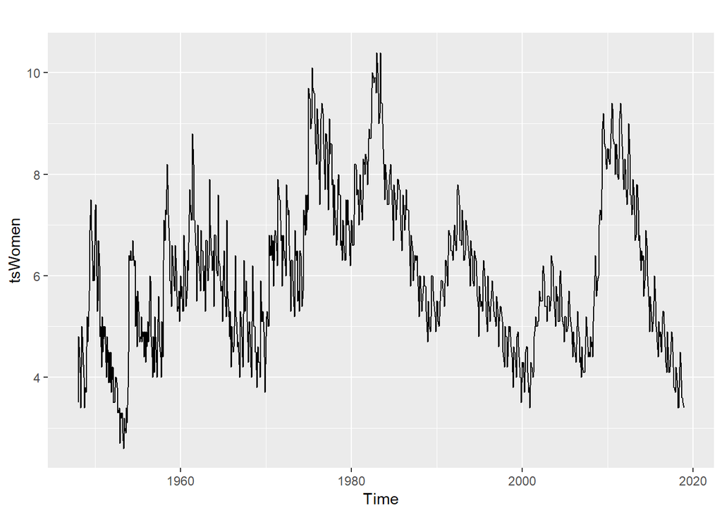

```r
tsWomen<-ts(TS.data$Value, frequency = 12, start = 1948)
autoplot(tsWomen)
```

Модель ряда скорее всего нельзя назвать ни аддитивной, ни мультипликативной. На графике можно заметить, что колебания сильнее в левой части, в то время как значение тренда там ниже, чем в других местах (так что модель не мультипликативная), при этом колебания нельзя назвать постоянными, так что и не вполне аддитивная. (Это все будет более заметно на графике остатков после удаления тренда.)

Автокорреляция ряда – это его корреляция со сдвинутой версией самого себя. Это важный показатель (для недетерминированных рядов), потому что, он показывает, влияют ли предыдущие состояния (запаздывающие наблюдения) временного ряда на текущее состояние (линейно). Таким образом, по диаграмме автокорреляции можно увидеть, есть ли тренд (опять же линейный, так как при сильно нелинейном тренде автокорреляции могут быть и очень малы).

На диаграмме автокорреляции, если автокорреляция пересекает пунктирную синюю линию, это означает, что конкретное запаздывание значимо коррелирует с текущим рядом (пунктирная синяя линия – граница доверительной области равенства нулю автокорреляции).

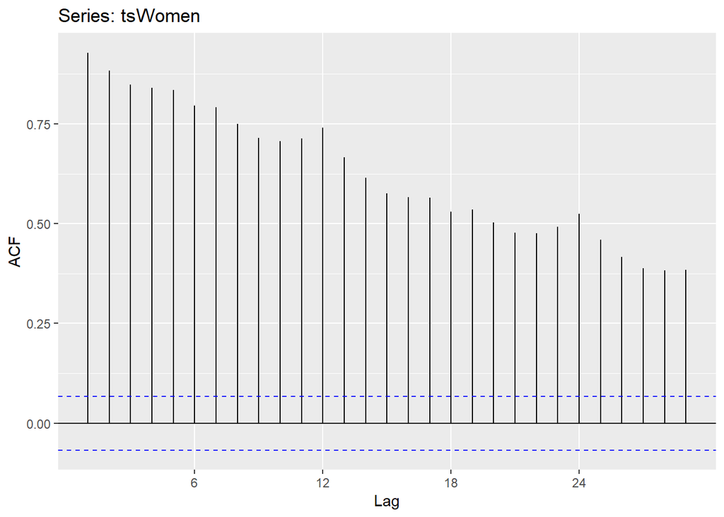

```r
ggAcf(tsWomen)
```

Тут видно, что есть тренд и периодичность (по годам).

Периодограмма ряда в обычной шкале:

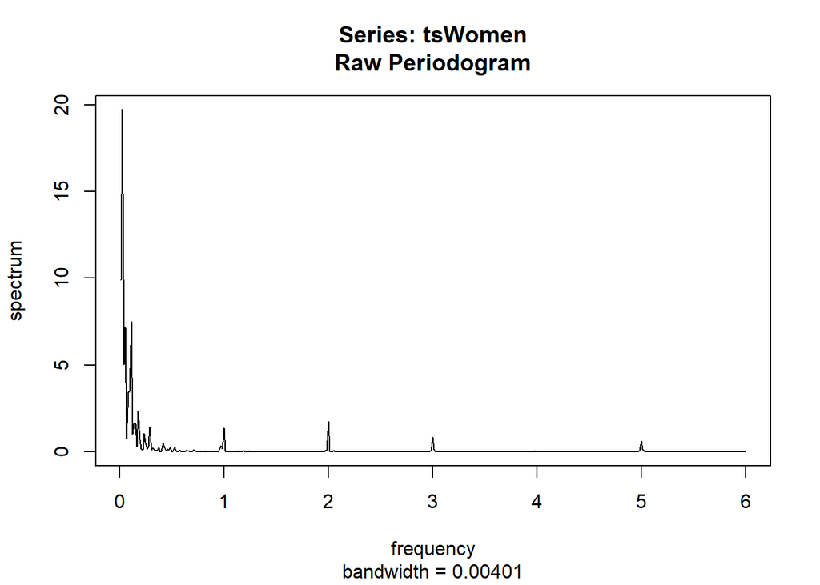

```r
spec.pgram(tsWomen,log="no")
```

## 1.2 Разложение ряда

### 1.2.1 Классическое сезонное разложение

Классическое сезонное разложение реализуется функцией decompose(). В этой функции можно выбрать, аддитивная модель или мультипликативная. У нас, как мы обсуждали выше, ни то, ни другое. Но в силу того, что увеличение шума в левой части ряда не слишком численно большое, будем считать, что это допустимо – применять метод, ориентированный на аддитивную модель.

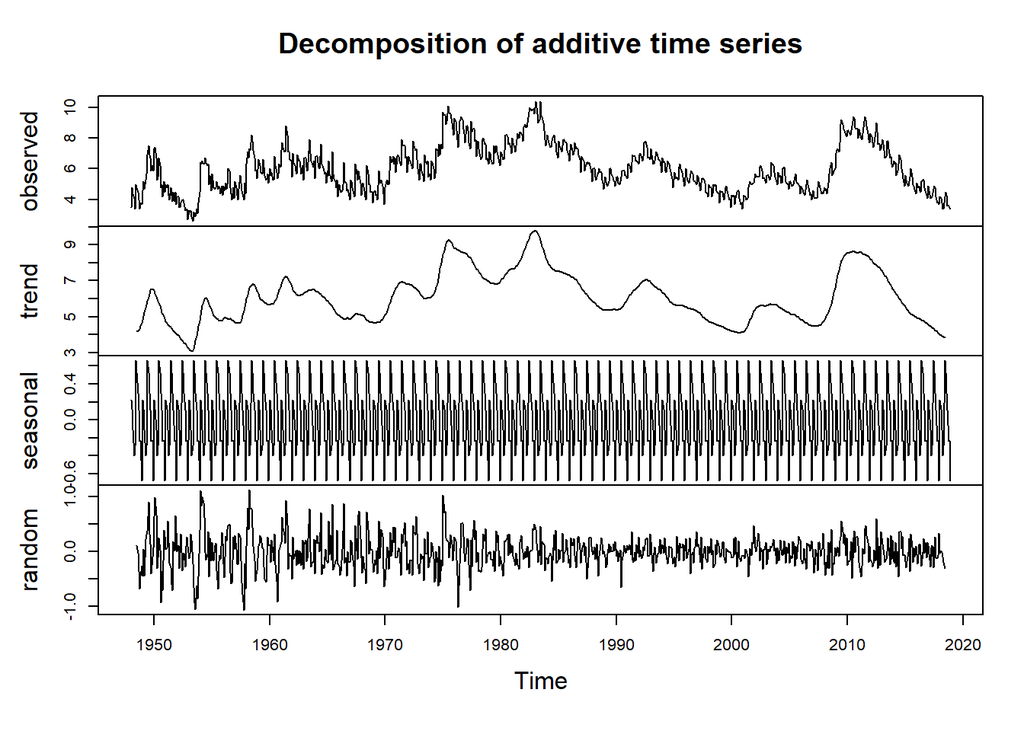

```r
Women.decompose<-stats::decompose(tsWomen, type="additive",filter = c(1/24,rep(1/12,11),1/24))
plot(Women.decompose)
```

Периодограмма шума:

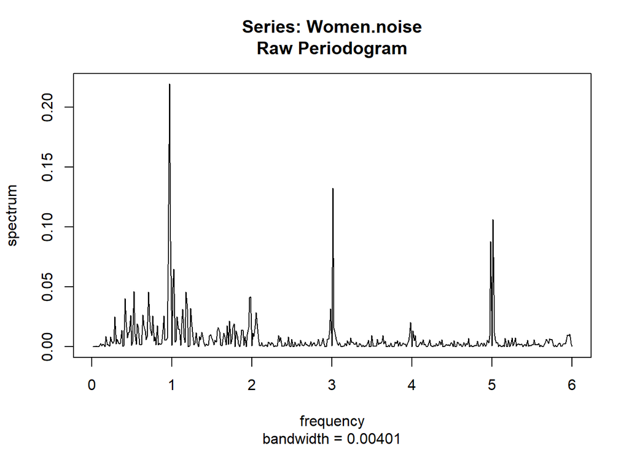

```r
Women.noise<-ts(tsWomen[-c(1:6,847:852)]-Women.decompose$seasonal[-c(1:6,847:852)]-Women.decompose$trend[-c(1:6,847:852)],frequency = 12)
spec.pgram(Women.noise, log="no")
```

Вот так вот. Периодичность в шуме есть и довольно приличная.

### 1.2.2 Усовершенствованное классическое сезонное разложение

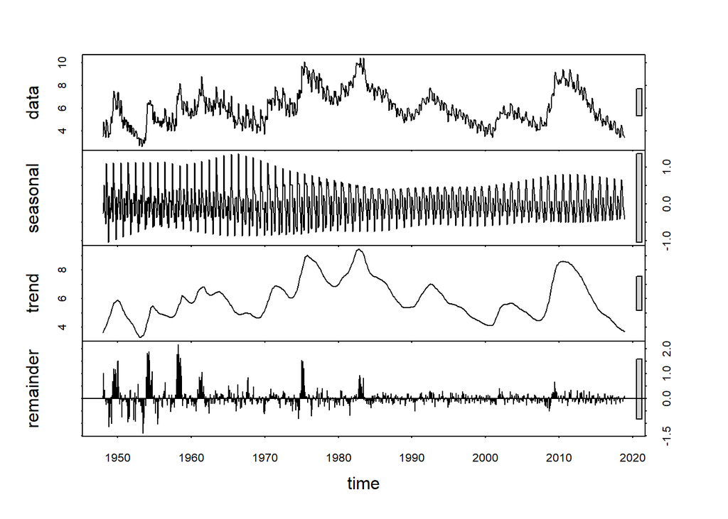

```r
Women.stl<-stl(tsWomen,s.window = 15,s.degree = 1, l.window = 36,robust = TRUE, outer=10)
plot(Women.stl)
```

Периодограмма шума:

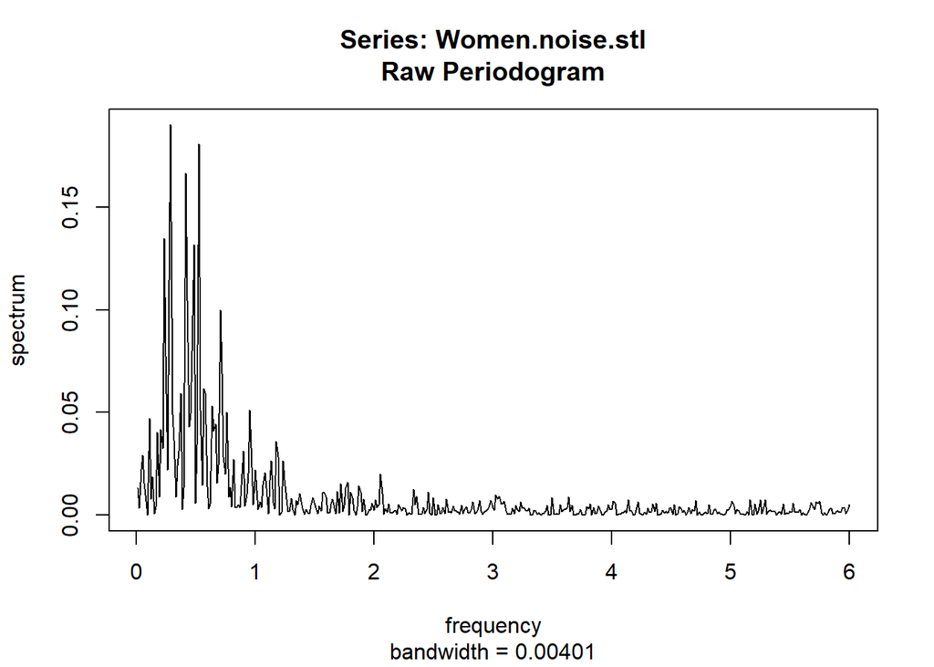

```r
Women.noise.stl<-ts((Women.stl$time.series)[,"remainder"],frequency = 12)
spec.pgram(Women.noise.stl, log="no")
```

От периодичности избавиться получилось. Однако в периодограмме шума выделяются низкие частоты. Либо мы оставили часть тренда, либо, что вполне вероятно, мы имеем дело с красным шумом. Скорее всего второй вариант…

Таким образом, надежд на то, что остаток – белый шум, особо нет.

```r
autocor.noise.stl<- autocorrelations(Women.noise.stl, maxlag = 30)
whiteNoiseTest(autocor.noise.stl, h0 = "iid",method = "LjungBox",interval=FALSE) #"LiMcLeod" (default), "LjungBox", "BoxPierce".
```

```
## $test
##         ChiSq DF       pvalue
## [1,] 389.5655  1 1.029106e-86
## attr(,"method")
## [1] "LjungBox"
##
## $ci
##      int
## [1,]   0 0
## attr(,"level")
## [1] FALSE
```

Не белый шум.

### 1.2.3 SSA

Посмотрим на график собственных чисел всего ряда.

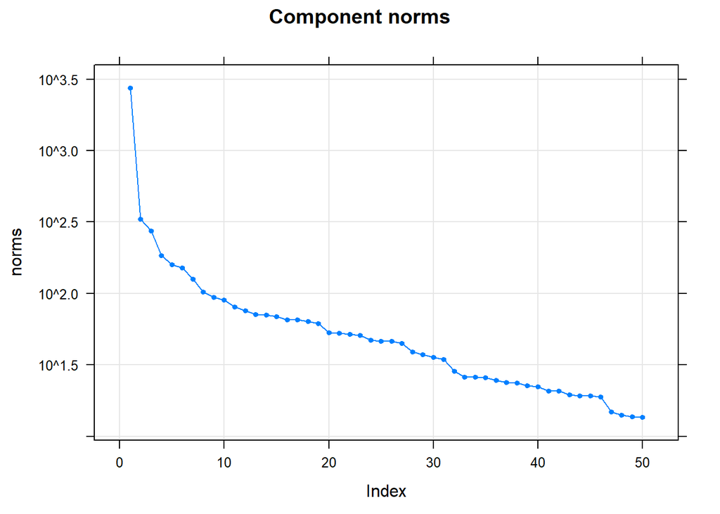

```r
Women.ssa<-ssa(tsWomen,L=420)
plot(Women.ssa)
```

График не очень приятный. Будет сложно отделить сигнал от шума (собственные числа близки).

Будем применять последовательный SSA. Для выделения тренда возьмем небольшую длину окна.

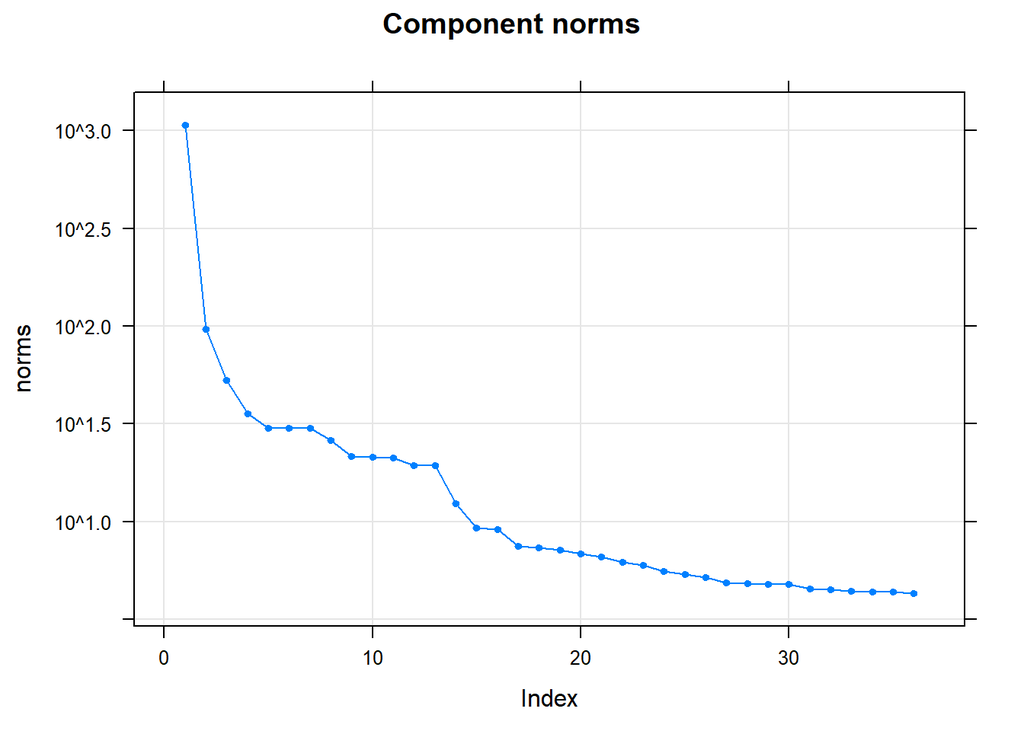

```r
trend.SSA<-ssa(tsWomen,L=36)
plot(trend.SSA)
```

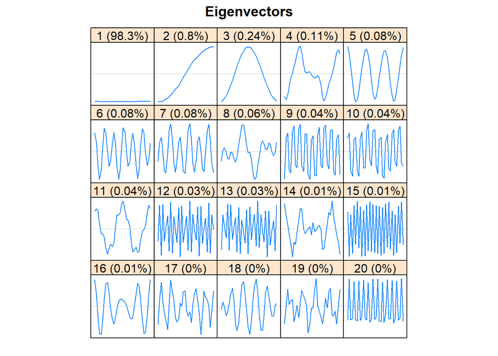

```r
plot(trend.SSA,type="vectors",idx=1:20)
```

Первые три компоненты есть тренд.

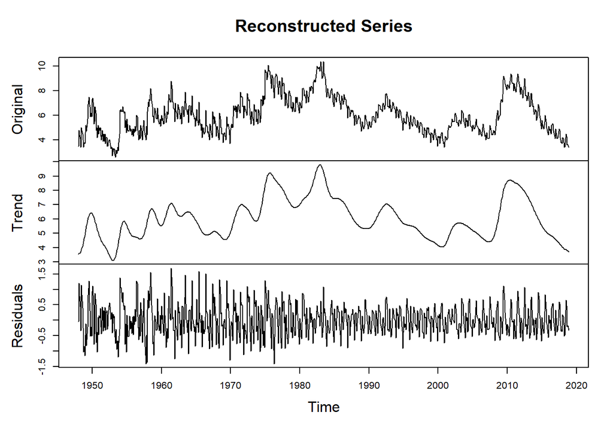

```r
plot(reconstruct(trend.SSA, groups = list(Trend=c(1:3)),
     plot.method = "xyplot", layout = c(1,7),
     add.residuals = FALSE, add.original = FALSE))
```

```r
trend.ssa.reconstruct<-reconstruct(trend.SSA, groups = list(Trend = 1:3))
Women.trend<-trend.ssa.reconstruct$Trend
```

Переходим к анализу ряда без тренда.

```r
Women.detrend<-ts(tsWomen-Women.trend,frequency = 12)
Women.detrend.ssa<-ssa(Women.detrend,L=420)
```

Построим периодограмму для полученного ряда без тренда:

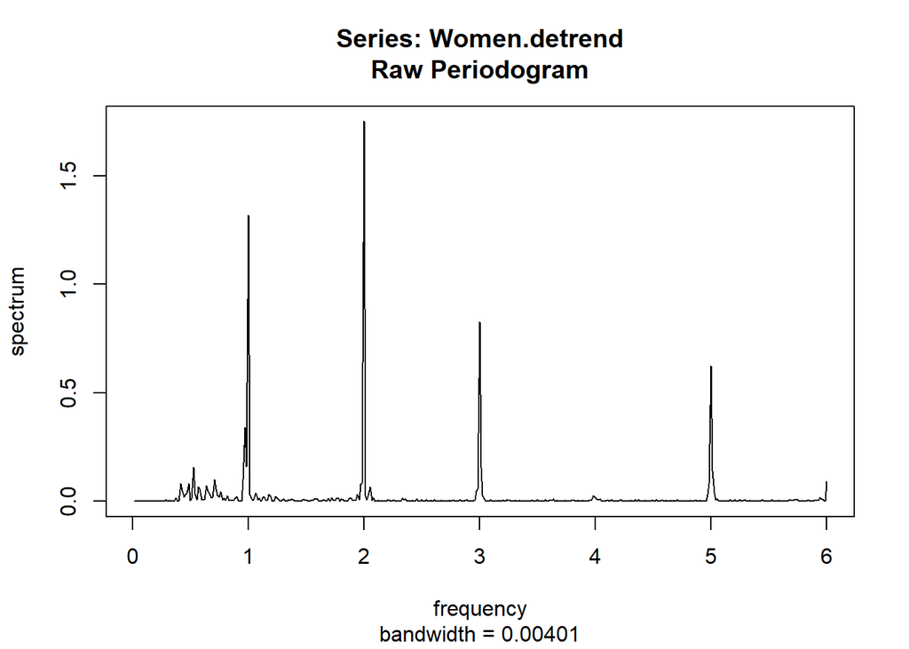

```r
spec.pgram(Women.detrend,log='no')
```

Как мы видели и раньше, присутствуют периоды 12, 6, 4, 2.4. И теперь еще немного выделились периоды 2 и 3, которых на периодограмме исходного ряда было не видно (из-за масштаба). Так что далее будем искать в том числе и пилу. И заметны повышенные низкие частоты.

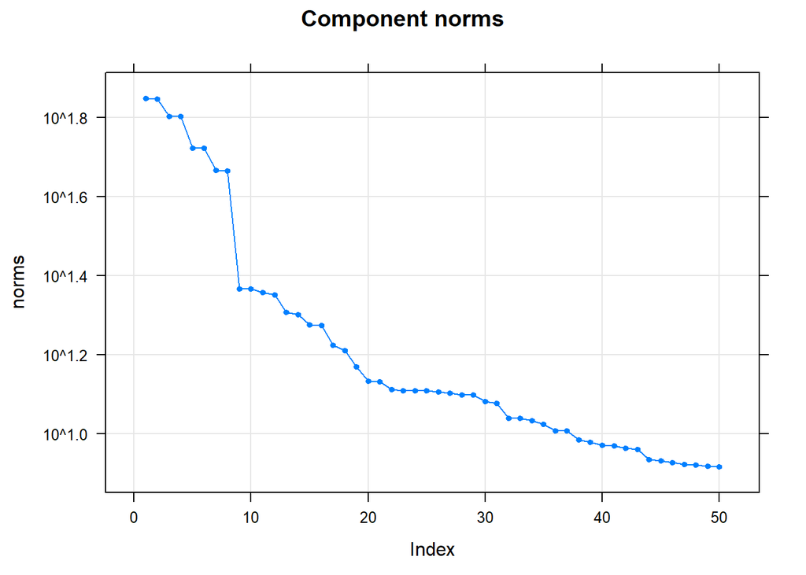

```r
plot(Women.detrend.ssa)
```

Четыре пары выделяются сильно. Но нет уверенности в том, что они возьмут всю периодичность (точнее, точно не возьмут, хотя бы потому, что мы теперь обнаружили больше периодов в ряде). Но сначала разберемся с очевидными.

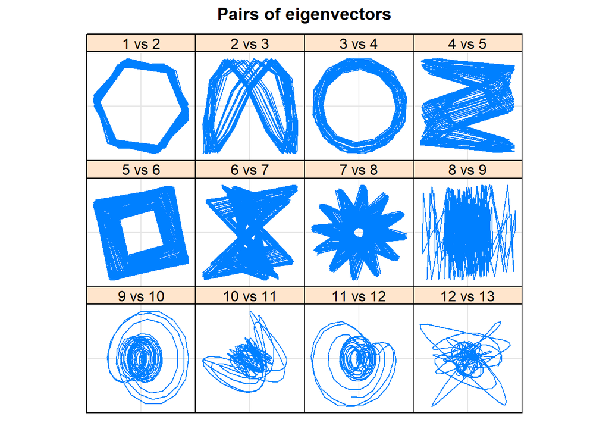

```r
plot(Women.detrend.ssa, type = "paired", idx = 1:12, plot.contrib = FALSE)
```

```r
parestimate(Women.detrend.ssa, groups = list(1:2,3:4,5:6,7:8,9:10,11:12), method = "esprit")
```

```
## $F1
##    period     rate   |    Mod     Arg  |     Re        Im
##     6.003  -0.000503 |  0.99950   1.05 |  0.50015   0.86536
##    -6.003  -0.000503 |  0.99950  -1.05 |  0.50015  -0.86536
##
## $F2
##    period     rate   |    Mod     Arg  |     Re        Im
##    12.033  -0.000421 |  0.99958   0.52 |  0.86638   0.49854
##   -12.033  -0.000421 |  0.99958  -0.52 |  0.86638  -0.49854
##
## $F3
##    period     rate   |    Mod     Arg  |     Re        Im
##     3.999  -0.001438 |  0.99856   1.57 | -0.00045   0.99856
##    -3.999  -0.001438 |  0.99856  -1.57 | -0.00045  -0.99856
##
## $F4
##    period     rate   |    Mod     Arg  |     Re        Im
##     2.399  -0.001808 |  0.99819   2.62 | -0.86496   0.49823
##    -2.399  -0.001808 |  0.99819  -2.62 | -0.86496  -0.49823
##
## $F5
##    period     rate   |    Mod     Arg  |     Re        Im
##    15.100  -0.012844 |  0.98724   0.42 |  0.90300   0.39903
##   -15.100  -0.012844 |  0.98724  -0.42 |  0.90300  -0.39903
##
## $F6
##    period     rate   |    Mod     Arg  |     Re        Im
##    19.595  -0.019228 |  0.98096   0.32 |  0.93095   0.30919
##   -19.595  -0.019228 |  0.98096  -0.32 |  0.93095  -0.30919
```

Первые 4 периодики не вызывают сомнений. Две последние и выглядят странно, и периоды у них странные.

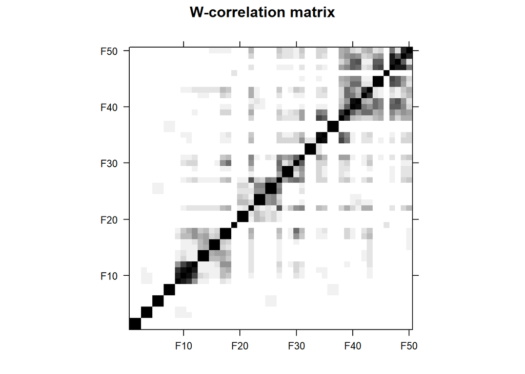

```r
plot(wcor(Women.detrend.ssa, groups = 1:50),
          scales = list(at = c(10, 20, 30,40,50)))
```

Также отчетливо выделяются 4 периодики. Но нам этого не достаточно. Сначала попробуем выведать все, что можно, из матрицы взвешенных корреляций. На ней можно заметить квадратики, особо не коррелирующие с остальными, но имеющие уже не очень большой вклад. Это пары 32-33 и 36-37. Также выделяется 19 и 46 компонента, они не коррелируют с остальными (только немного между собой).

Возможно, компоненты 19 и 46 – это две пилы. Посмотрим, как они выглядят:

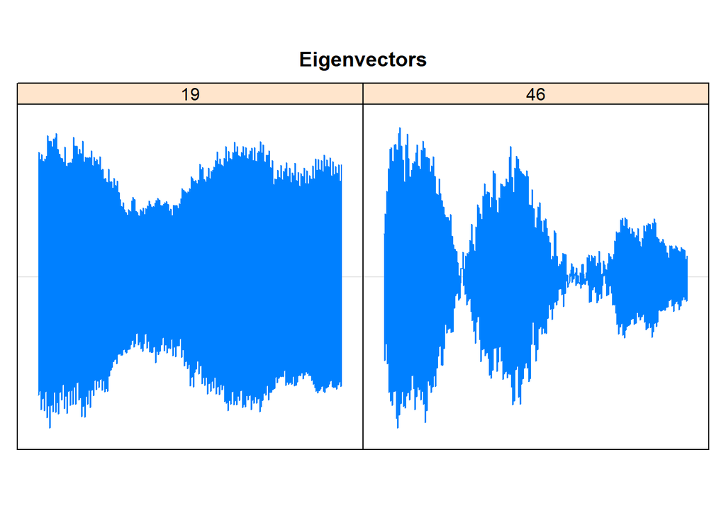

```r
plot(Women.detrend.ssa, type = "vectors", idx = c(19,46), plot.contrib = FALSE)
```

19 похожа на пилу, а 46 смесь чего-то (имеет сильную модуляцию).

Проверим теперь пары 32-33 и 36-37.

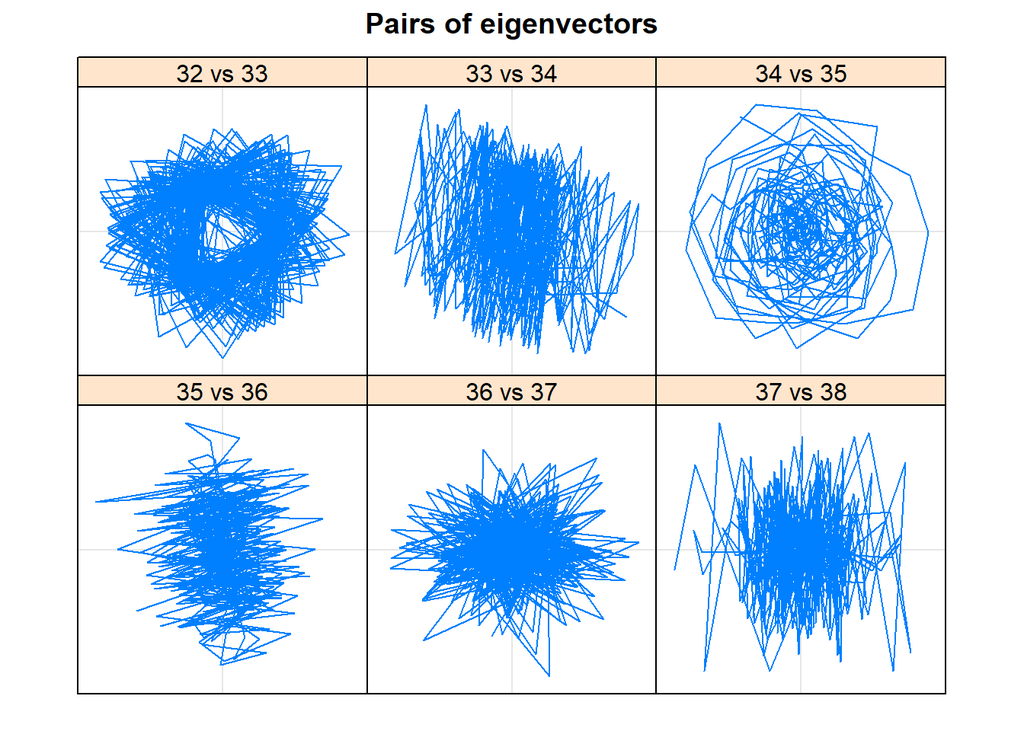

```r
plot(Women.detrend.ssa, type = "paired", idx = 32:37, plot.contrib = FALSE)
```

```r
parestimate(Women.detrend.ssa, groups = list(32:33,36:37), method = "esprit")
```

```
## $F1
##    period     rate   |    Mod     Arg  |     Re        Im
##     3.066  -0.044602 |  0.95638   2.05 | -0.44015   0.84907
##    -3.066  -0.044602 |  0.95638  -2.05 | -0.44015  -0.84907
##
## $F2
##    period     rate   |    Mod     Arg  |     Re        Im
##     2.415  -0.041079 |  0.95975   2.60 | -0.82323   0.49338
##    -2.415  -0.041079 |  0.95975  -2.60 | -0.82323  -0.49338
```

Периоды этих парочек выглядят правдоподобно: 3 и 2.4. Такие периоды для нас актуальны.

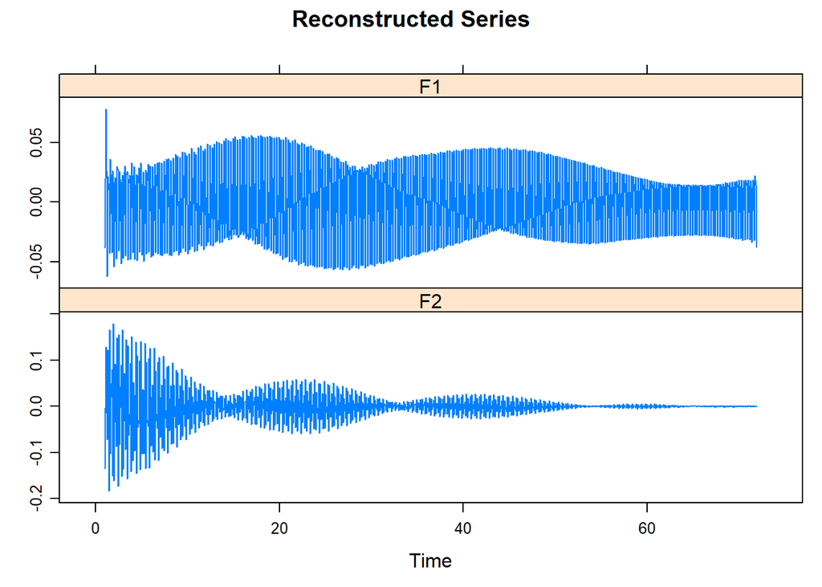

```r
plot(reconstruct(Women.detrend.ssa, groups = list(32:33,36:37)),
     plot.method = "xyplot", layout = c(1,2),
     add.residuals = FALSE, add.original = FALSE)
```

Берем все рассмотренные компоненты в сезонность (они описывают периоды 6,12, 4, 2.4, 3, 2):

```r
Women.detrend.reconstruct <- reconstruct(Women.detrend.ssa,
                      groups = list(Seasonality = c(1:8,19,46,32:33,36:37)))
```

Периодограмма остатка:

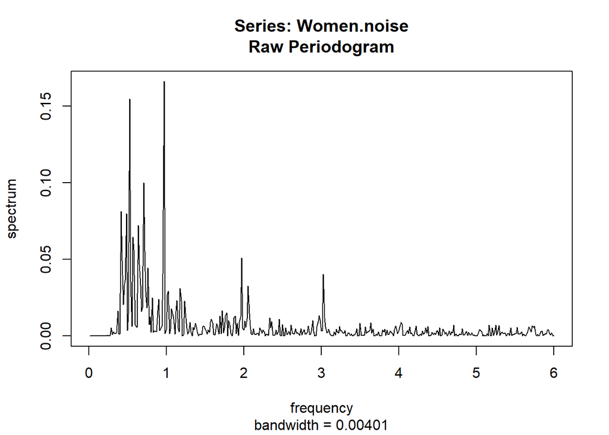

```r
Women.noise<-ts(Women.detrend-Women.detrend.reconstruct$Seasonality,frequency = 12)
spec.pgram(Women.noise, log="no")
```

Все еще остались периоды 12, 6 и 4.

Снова посмотрим на матрицу взвешенных корреляций:

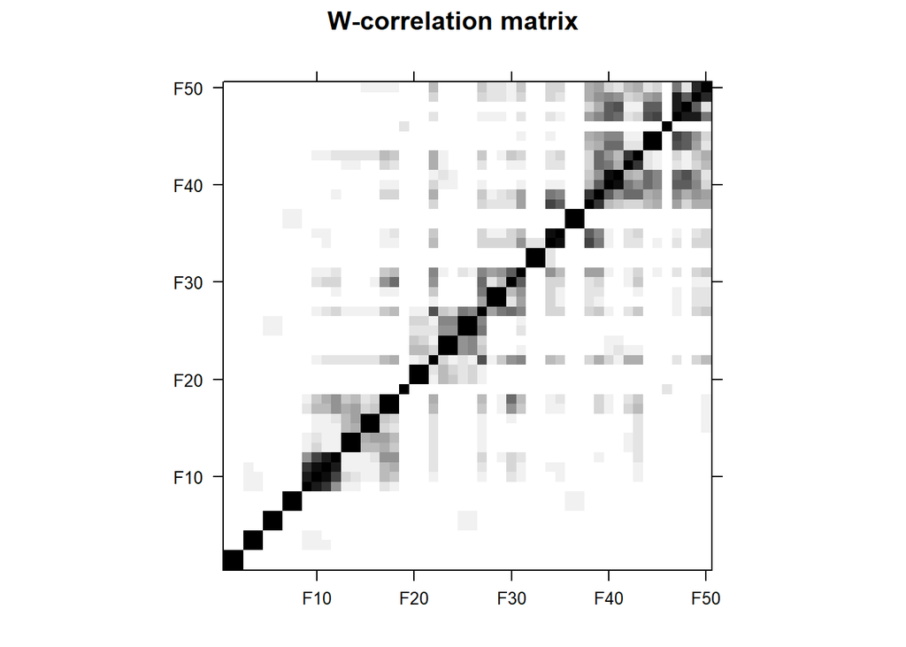

```r
plot(wcor(Women.detrend.ssa, groups = 1:50),
          scales = list(at = c(10, 20, 30,40,50)))
```

Заметим, что компоненты 20-21,23-24,25-26 образуют блок компонент, которые коррелируют между собой, но не коррелируют с другими.

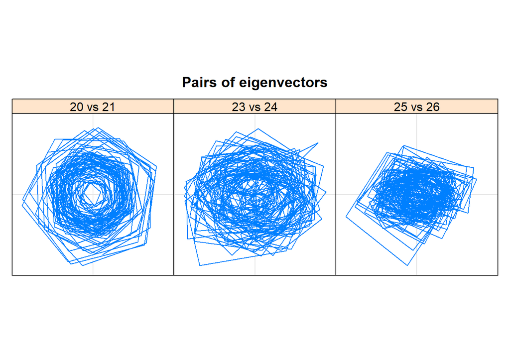

```r
plot(Women.detrend.ssa, type = "paired", idx = c(20,23,25), idy = c(21,24,26), plot.contrib = FALSE)
```

```r
parestimate(Women.detrend.ssa, groups = list(20:21,23:24,25:26), method = "esprit")
```

```
## $F1
##    period     rate   |    Mod     Arg  |     Re        Im
##     6.033  -0.015663 |  0.98446   1.04 |  0.49708   0.84975
##    -6.033  -0.015663 |  0.98446  -1.04 |  0.49708  -0.84975
##
## $F2
##    period     rate   |    Mod     Arg  |     Re        Im
##     6.002  -0.140996 |  0.86849   1.05 |  0.43449   0.75200
##    -6.002  -0.140996 |  0.86849  -1.05 |  0.43449  -0.75200
##
## $F3
##    period     rate   |    Mod     Arg  |     Re        Im
##     4.733  -0.236549 |  0.78935   1.33 |  0.19004   0.76613
##    -4.733  -0.236549 |  0.78935  -1.33 |  0.19004  -0.76613
```

Похоже, что пары 20-21 и 23-24 – это перемешавшиеся периодики с периодом 6. Пара 25-26 имеет неправдоподобный период 4.7, но при этом очень сильно коррелирует с парой 23-24. Это странно. В итоге эта пара перебивает период 4, так что ее тоже нужно брать. (возможно, при помощи iossa это тоже получится подкрутить).

Другой блок (9:18) не похож на перемешавшиеся периодики, тк коррелирует и с остальными. Однако мы до сих пор не нашли недостающую гармонику с периодом 12. Проверим периоды на всякий случай:

```r
parestimate(Women.detrend.ssa, groups = list(9:10,11:12,13:14,15:16,17:18), method = "esprit")
```

```
## $F1
##    period     rate   |    Mod     Arg  |     Re        Im
##    15.100  -0.012844 |  0.98724   0.42 |  0.90300   0.39903
##   -15.100  -0.012844 |  0.98724  -0.42 |  0.90300  -0.39903
##
## $F2
##    period     rate   |    Mod     Arg  |     Re        Im
##    19.595  -0.019228 |  0.98096   0.32 |  0.93095   0.30919
##   -19.595  -0.019228 |  0.98096  -0.32 |  0.93095  -0.30919
##
## $F3
##    period     rate   |    Mod     Arg  |     Re        Im
##    17.935  -0.005452 |  0.99456   0.35 |  0.93415   0.34134
##   -17.935  -0.005452 |  0.99456  -0.35 |  0.93415  -0.34134
##
## $F4
##    period     rate   |    Mod     Arg  |     Re        Im
##    19.511  -0.001420 |  0.99858   0.32 |  0.94725   0.31604
##   -19.511  -0.001420 |  0.99858  -0.32 |  0.94725  -0.31604
##
## $F5
##    period     rate   |    Mod     Arg  |     Re        Im
##    21.931  -0.011408 |  0.98866   0.29 |  0.94836   0.27939
##   -21.931  -0.011408 |  0.98866  -0.29 |  0.94836  -0.27939
```

Пара 9:10 имеет период примерно 15. Однако, так как ближе к 12ти ничего другого нет, пробуем ее добавить и, о чудо, эта пара справляется с периодом 12. (так, видимо, тоже получилось из-за того, что гармоники перемешались)

Обновим результат.

```r
Women.detrend.reconstruct <- reconstruct(Women.detrend.ssa,
                      groups = list(Seasonality = c(1:8,9:10,19,20:21,23:24,25:26,32:33,36:37)))
```

Периодограмма шума:

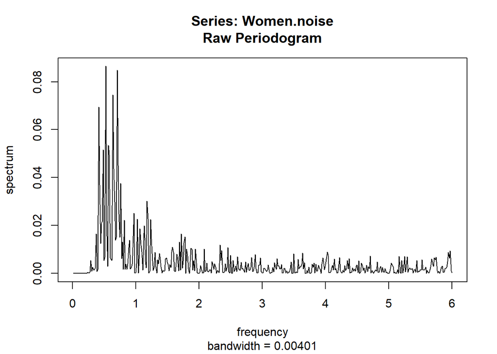

```r
Women.noise<-ts(Women.detrend-Women.detrend.reconstruct$Seasonality,frequency = 12)
spec.pgram(Women.noise, log="no")
```

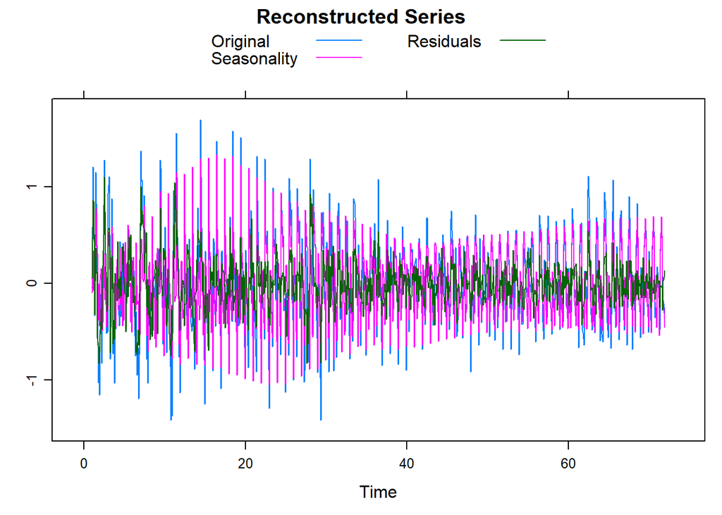

```r
plot(Women.detrend.reconstruct , add.residuals = TRUE, add.original = TRUE,
     plot.method = "xyplot",
     superpose = TRUE, auto.key = list(columns = 2))
```

# 2 Модельные ряды

Модельные данные (COL4, COL10).

```r
ts.data<-read.table("stud2005.csv",header = TRUE,dec=",",sep = ";")
ts4<-ts(ts.data$COL4)
ts10<-ts(na.omit(ts.data$COL10))
```

## 2.1 Ряд COL4

Разберемся сначала с рядом COL4.

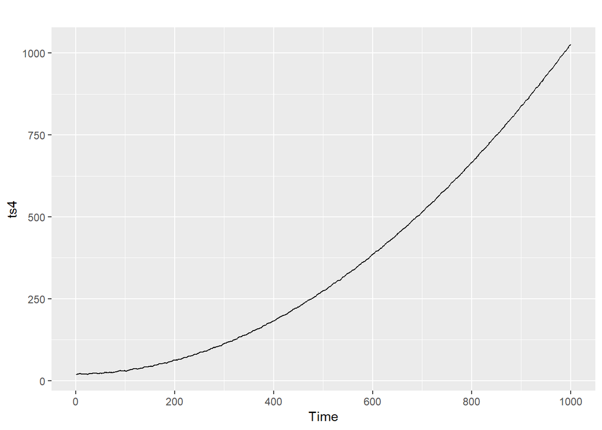

```r
autoplot(ts4)
```

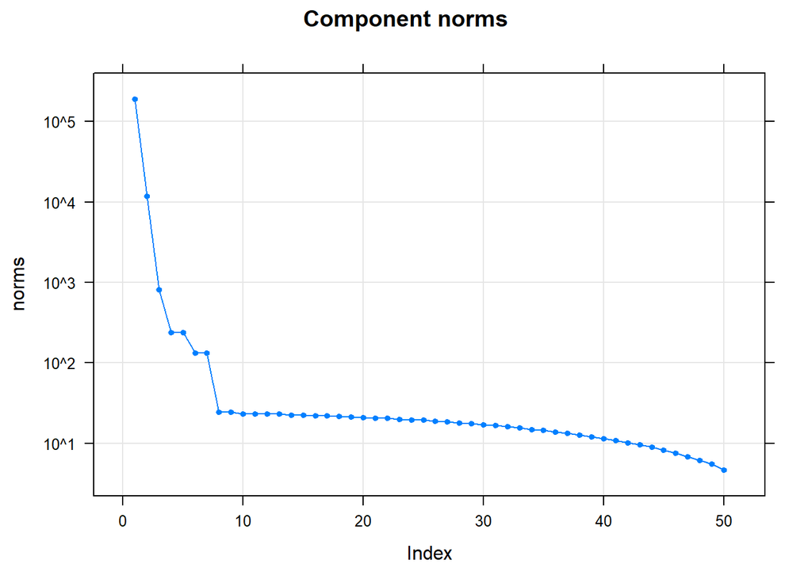

```r
ssa4<-ssa(ts4, L=500)
plot(ssa4)
```

Уже по этому графику можно увидеть пары одинаковых собственных чисел (4-5 и 6-7), а также то, что, начиная с 8й компоненты, собственные числа мало отличаются. Возможно, стоит рассматривать как раз 7 первых компонент.

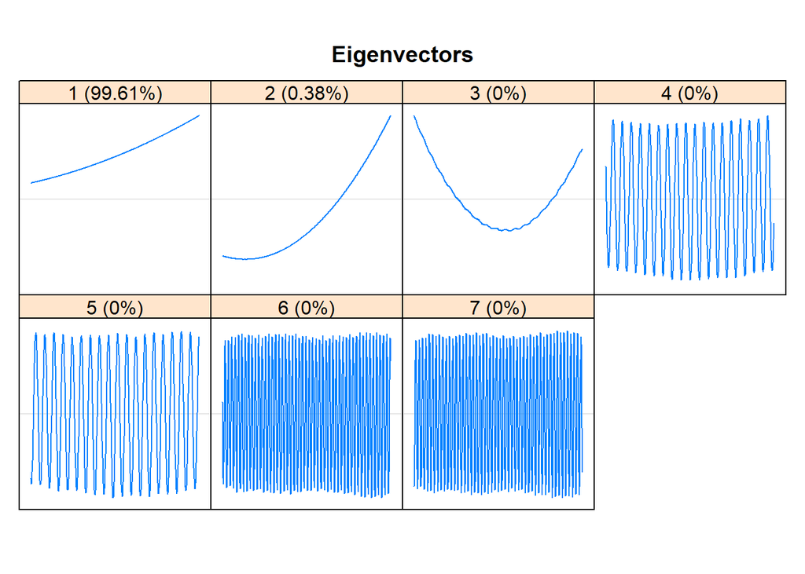

```r
plot(ssa4, type = "vectors", idx = 1:7)
```

Первые три собственнх вектора соответствуют тренду. Рассмотрим попарно остальные.

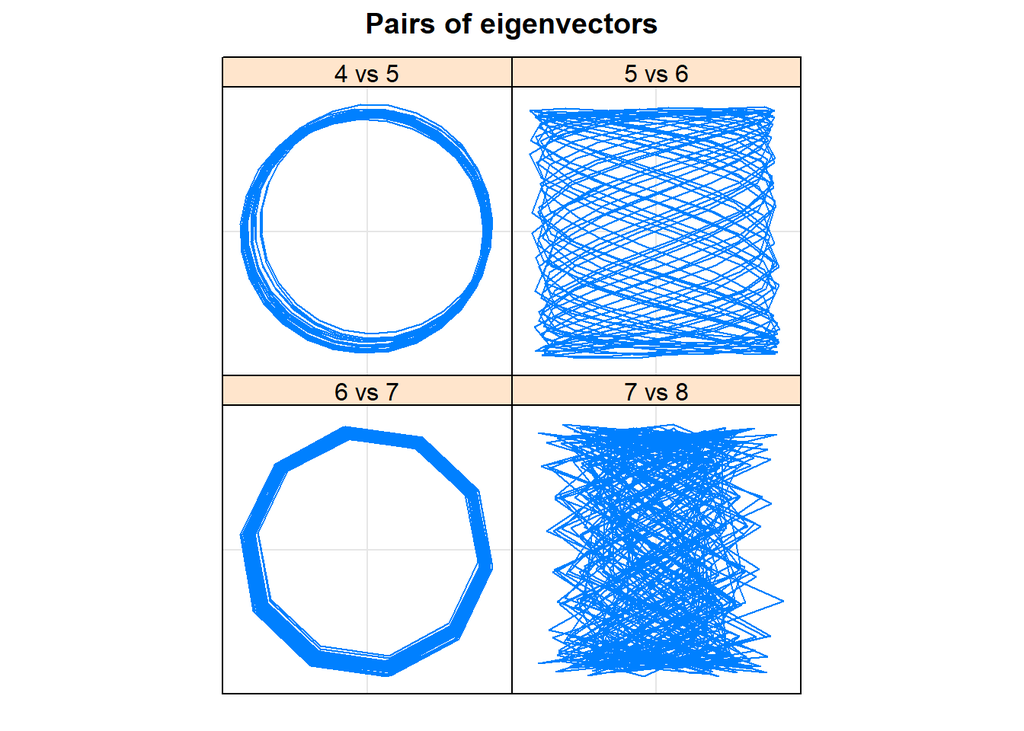

```r
plot(ssa4, type = "paired", idx = 4:7, plot.contrib = FALSE)
```

Видим, что векторы 4-5 и 6-7 образуют пары. 6-7 с периодом 10, а 4-5 не понятно, какой-то большой период, уточним:

```r
print(parestimate(ssa4, groups = list(4:5),
                  method =  "esprit"))
```

```
##    period     rate   |    Mod     Arg  |     Re        Im
##    26.987   0.000111 |  1.00011   0.23 |  0.97313   0.23075
##   -26.987   0.000111 |  1.00011  -0.23 |  0.97313  -0.23075
```

Период пары 4-5 равен 27.

Reconstructed series:

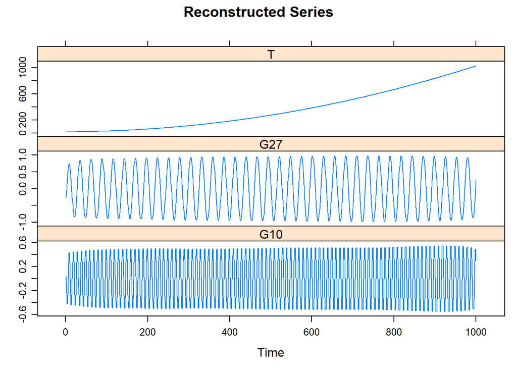

```r
plot(reconstruct(ssa4, groups = list(T=1:3,G27 = 4:5, G10 = 6:7)),
     plot.method = "xyplot", layout = c(1,3),
     add.residuals = FALSE, add.original = FALSE)
```

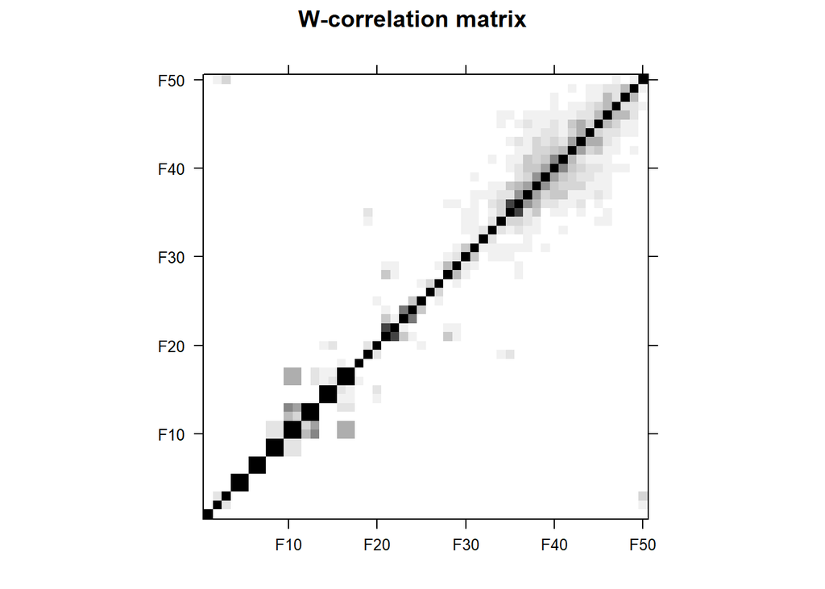

```r
plot(wcor(ssa4, groups = 1:50),
          scales = list(at = c(10, 20, 30,40,50)))
```

Первые три квадратика – тренд (не коррелируют с остальными…почти (2 и 3 коррелируют друг с другом немного)). Следующие два квадратика – 2 гармоники (синусы сильно коррелируют с соответствующими косинусами в паре и не коррелируют ни с чем остальным). Остальное – шум.

Положим первые 3 компоненты в тренд, 4:7 – в периодичность.

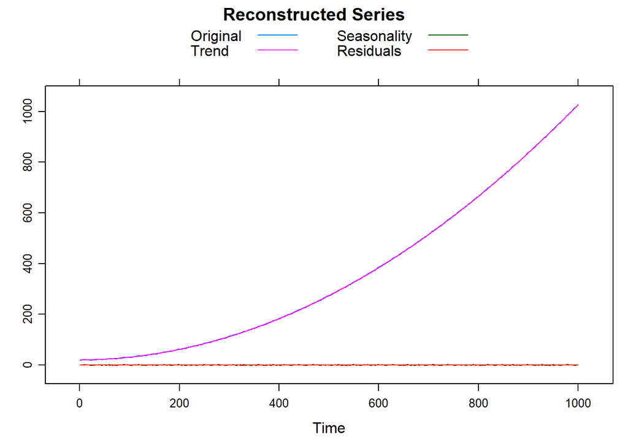

```r
reconstruct4<- reconstruct(ssa4,
                      groups = list(Trend = 1:3,
                                    Seasonality = 4:7))
plot(reconstruct4, add.residuals = TRUE, add.original = TRUE,
     plot.method = "xyplot",
     superpose = TRUE, auto.key = list(columns = 2))
```

Периодограмма остатков:

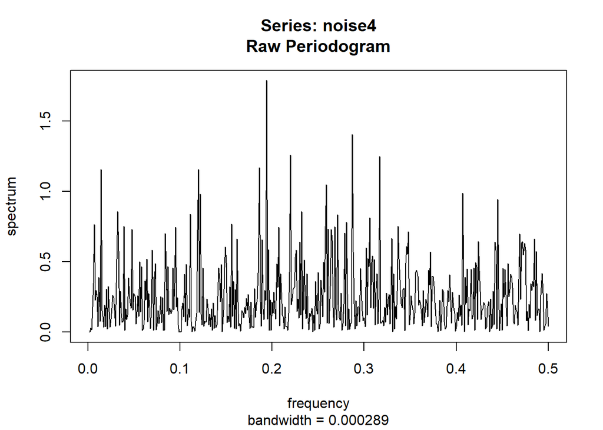

```r
noise4<-ts4-reconstruct4$Trend-reconstruct4$Seasonality
spec.pgram(noise4,log="no")
```

Внешне похоже на белый шум. Проверим.

```r
autocor.noise<- autocorrelations(noise4, maxlag = 30)
#plot(autocor.noise)
whiteNoiseTest(autocor.noise, h0 = "iid",method = "LjungBox",interval=FALSE) #"LiMcLeod" (default), "LjungBox", "BoxPierce".
```

```
## $test
##          ChiSq DF    pvalue
## [1,] 0.8473242  1 0.3573104
## attr(,"method")
## [1] "LjungBox"
##
## $ci
##      int
## [1,]   0 0
## attr(,"level")
## [1] FALSE
```

Гипотеза о том, что остался белый шум не отверглась.

## 2.2 Ряд COL10

Разбираемся со вторым модельным рядом.

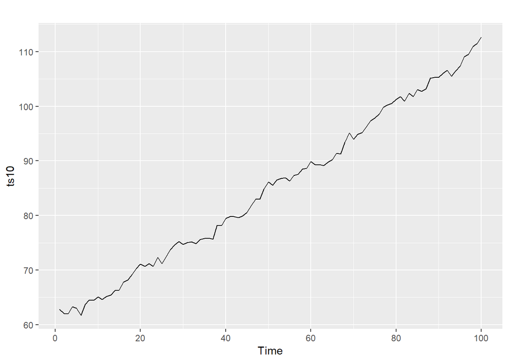

```r
autoplot(ts10)
```

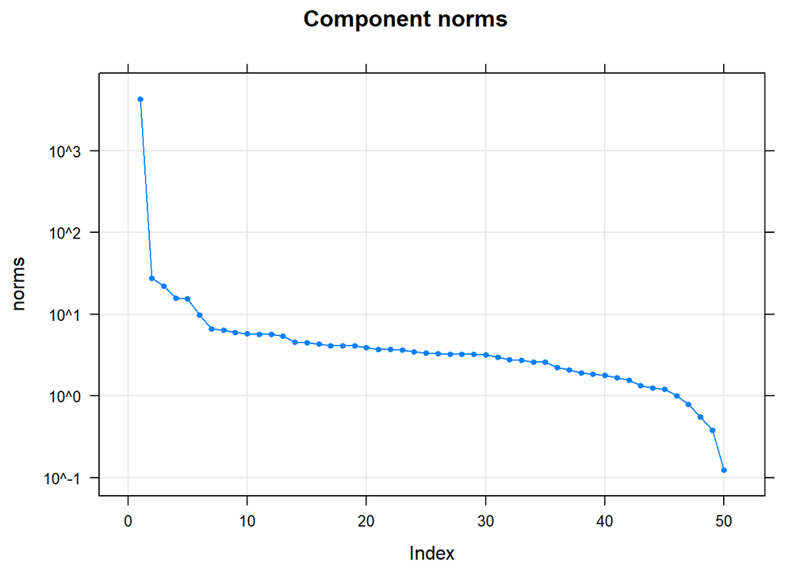

```r
ssa10<-ssa(ts10, L=50)
plot(ssa10)
```

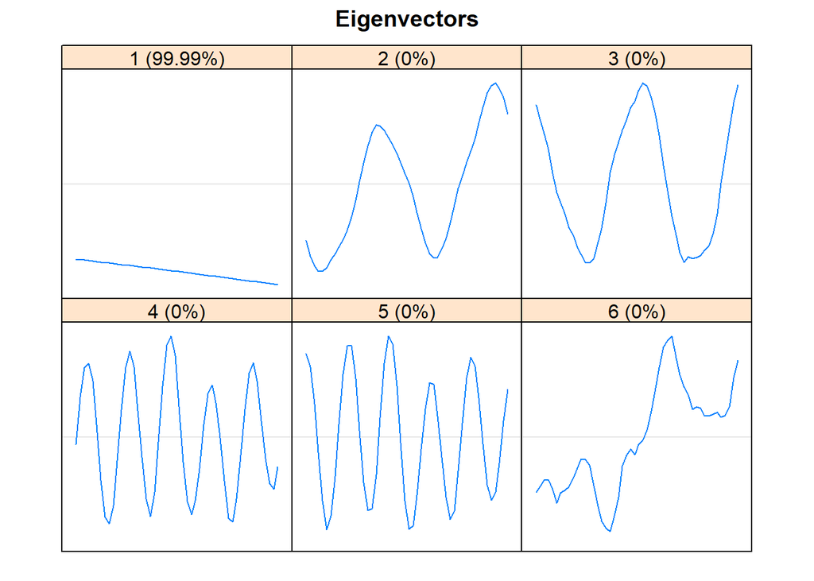

```r
plot(ssa10, type = "vectors", idx = 1:6)
```

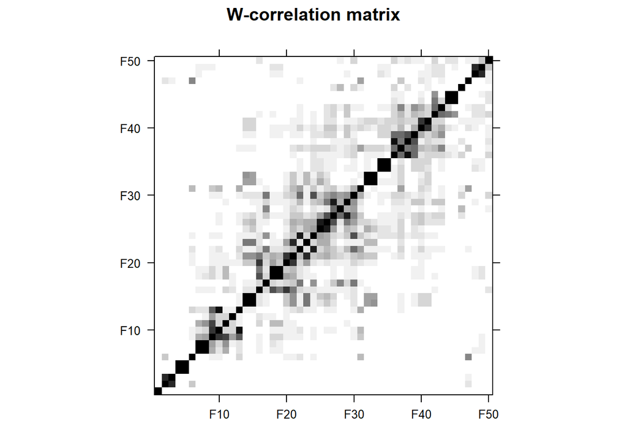

```r
plot(wcor(ssa10, groups = 1:50),
          scales = list(at = c(10, 20, 30,40,50)))
```

Первая компонента – тренд. 6я – тоже часть тренда. И часть тренда смешалась с одной из гармоник (она как бы поднимается). Таким образом, принимаем компоненты 1-6 за сигнал и применяем iossa, чтобы лучше отделить тренд и периодичность.

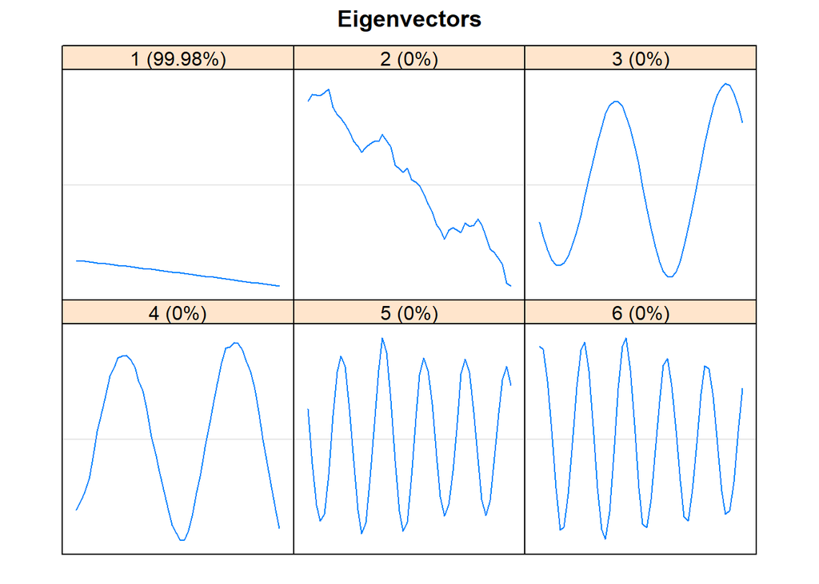

```r
iossa10<-iossa(ssa10, nested.groups = list(c(1,6),2:3,4:5))
plot(iossa10, type="vectors",idx=1:6)
```

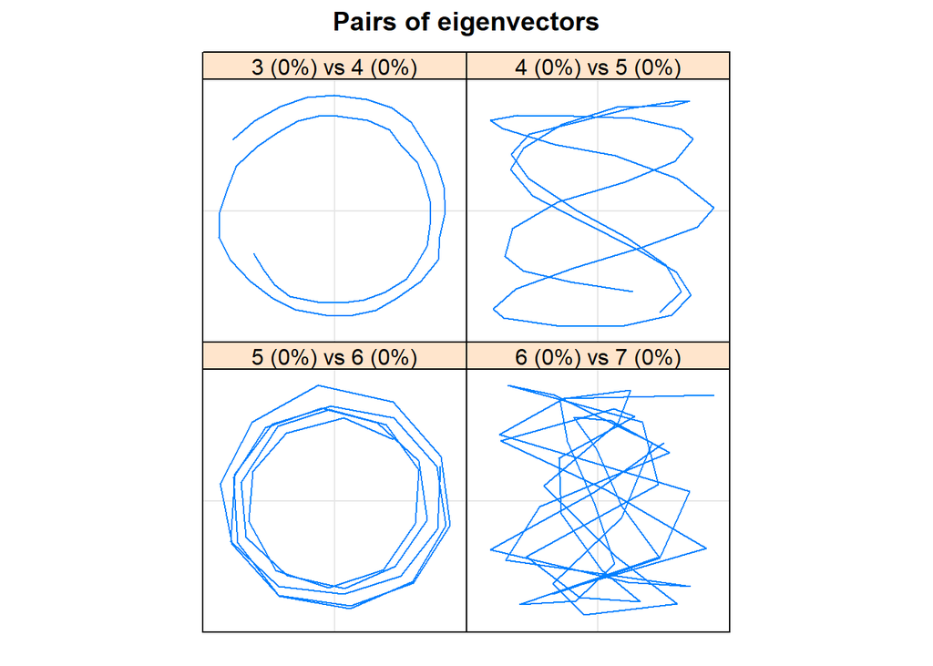

```r
plot(iossa10, type="paired",idx=3:6)
```

1-2 – тренд, 3-4, 5-6 теперь периодики (iossa переупорядочила с.в.)

Периоды:

```r
print(parestimate(iossa10, groups = list(3:4,5:6), method = "esprit"))
```

```
## $F1
##    period     rate   |    Mod     Arg  |     Re        Im
##    26.942   0.006007 |  1.00603   0.23 |  0.97879   0.23249
##   -26.942   0.006007 |  1.00603  -0.23 |  0.97879  -0.23249
##
## $F2
##    period     rate   |    Mod     Arg  |     Re        Im
##     9.983  -0.005858 |  0.99416   0.63 |  0.80367   0.58521
##    -9.983  -0.005858 |  0.99416  -0.63 |  0.80367  -0.58521
```

Получили, что периоды равны 27 и 10 (примерно). Знаем, что это правда. А без iossa никак не получалось получить период 27, ура.

Reconstructed series:

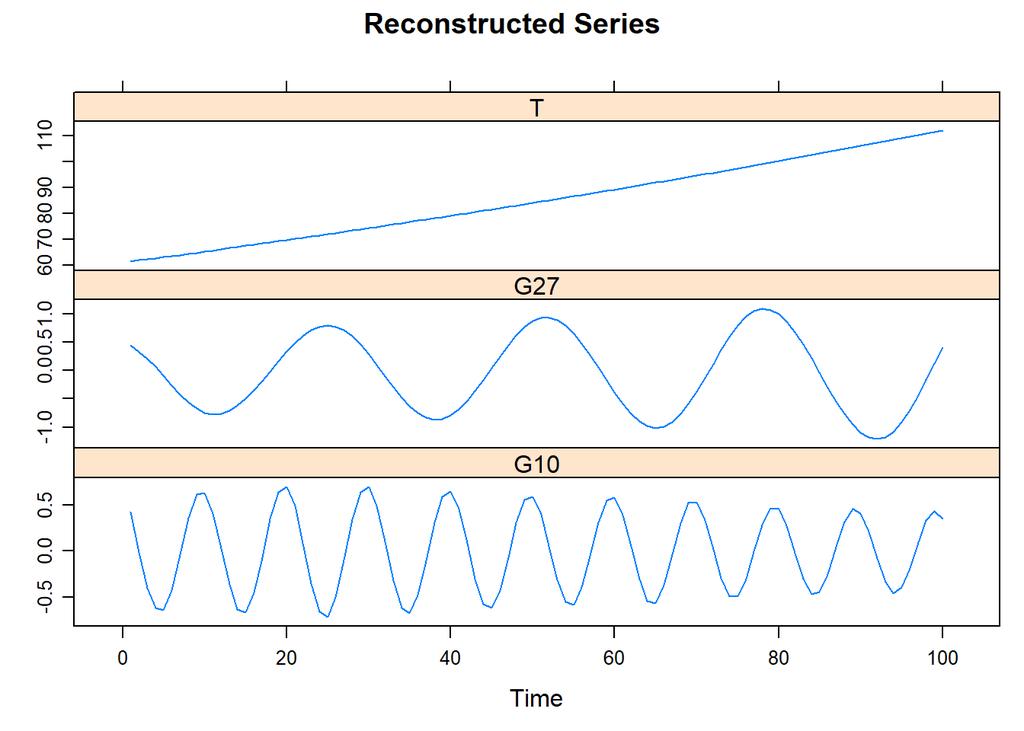

```r
plot(reconstruct(iossa10, groups = list(T=1:2,G27 = 3:4, G10 = 5:6)),
     plot.method = "xyplot", layout = c(1,3),
     add.residuals = FALSE, add.original = FALSE)
```

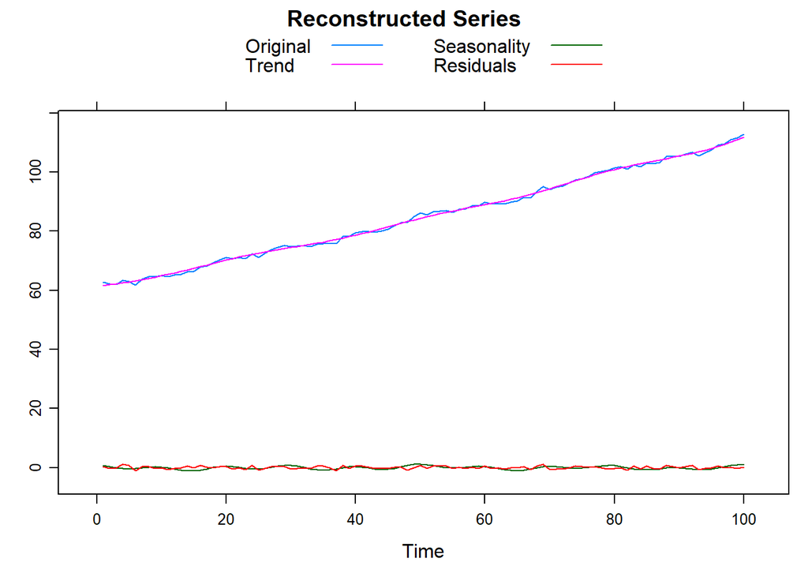

```r
reconstruct10<- reconstruct(ssa10,
                      groups = list(Trend = 1:2,
                                    Seasonality = 3:6))
plot(reconstruct10, add.residuals = TRUE, add.original = TRUE,
     plot.method = "xyplot",
     superpose = TRUE, auto.key = list(columns = 2))
```

Периодограмма остатков:

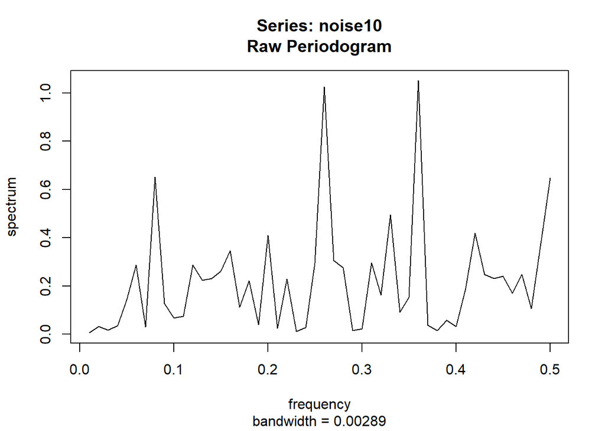

```r
noise10<-ts10-reconstruct10$Trend-reconstruct10$Seasonality
spec.pgram(noise10,log="no")
```

С одной стороны, вроде как похоже на оставшуюся периодичность (пики). Но наблюдений так мало, что это вполне могут быть просто случайные пики.

Проверка гипотезы о том, что остаток – белый шум.

```r
autocor.noise10<- autocorrelations(noise10, maxlag = 10)
whiteNoiseTest(autocor.noise10, h0 = "iid",method = "LjungBox",interval=FALSE) #"LiMcLeod" (default), "LjungBox", "BoxPierce".
```

```
## $test
##         ChiSq DF    pvalue
## [1,] 1.847284  1 0.1740996
## attr(,"method")
## [1] "LjungBox"
##
## $ci
##      int
## [1,]   0 0
## attr(,"level")
## [1] FALSE
```

Гипотеза не отвергается.

## 2.3 Ряд для построения огибающей

Смоделируем ряд $x_{n}=\exp(-n/100)*n^{2}\cos(\pi n/3)$.

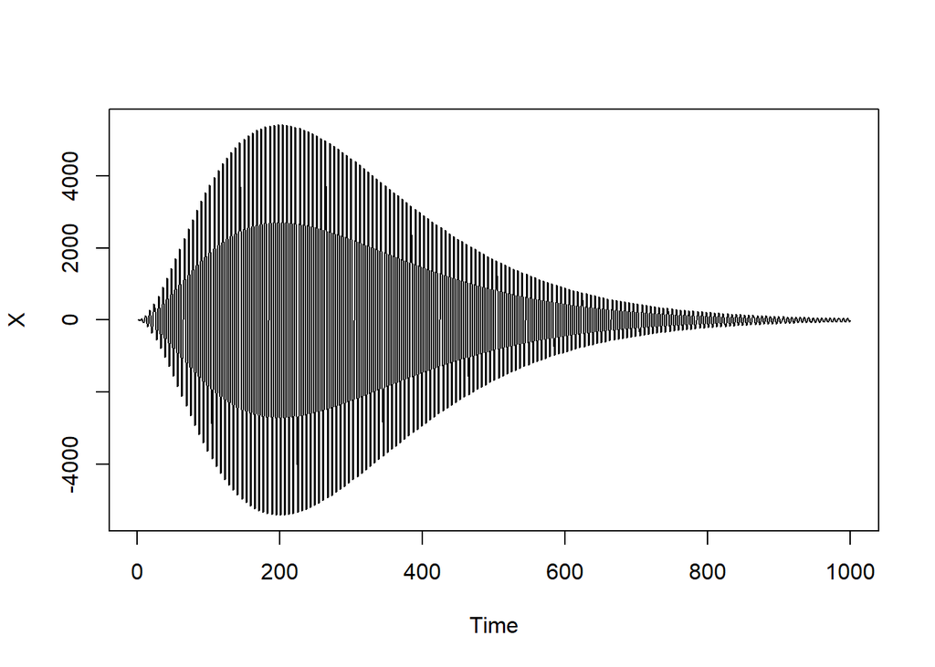

```r
N<-1:1000
X<-ts(exp(-N/100)*N*N*cos(pi*1/3*N))
plot.ts(X)
```

Возводим в квадрат и выделяем тренд.

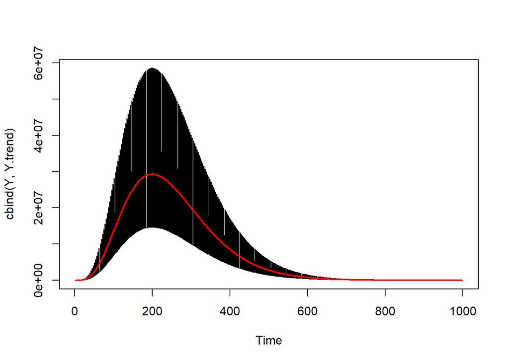

```r
Y<-2*X*X
Y.trend<-ma(Y, order = 6)
plot.ts(cbind(Y, Y.trend), plot.type = 'single', col = c('black', 'red'),lwd=c(1,2))
```

Получаем огибающую:

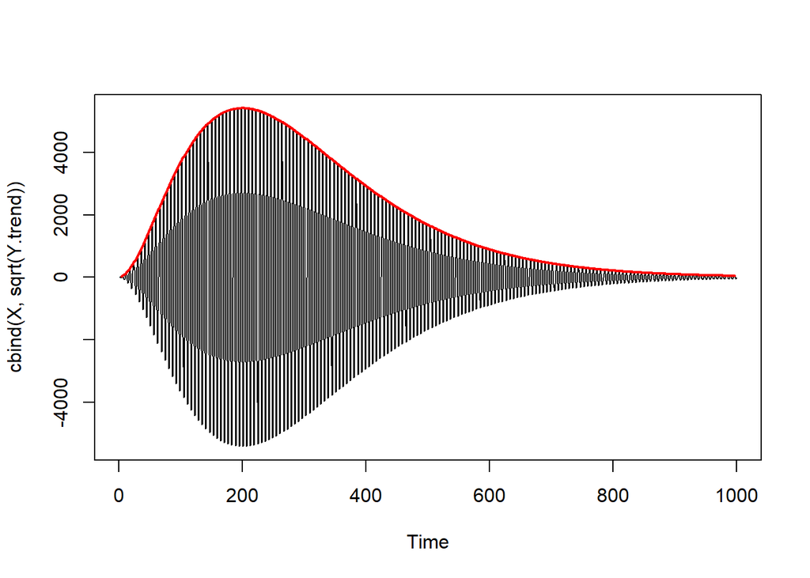

```r
plot.ts(cbind(X, sqrt(Y.trend)), plot.type = 'single', col = c('black', 'red','green'),lwd=c(1,2))
```